# Relative healthcare use (Dialysis)

Transplant appointments (overall)

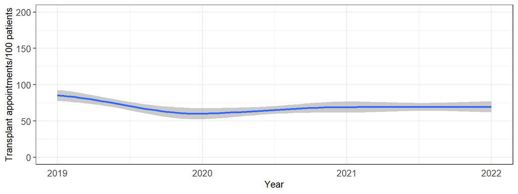

Transplant appointments by ethnicity

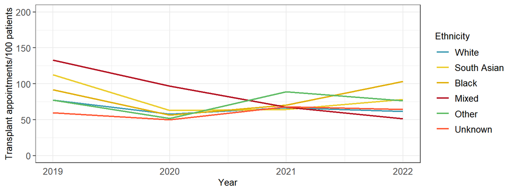

Transplant appointments by IMD

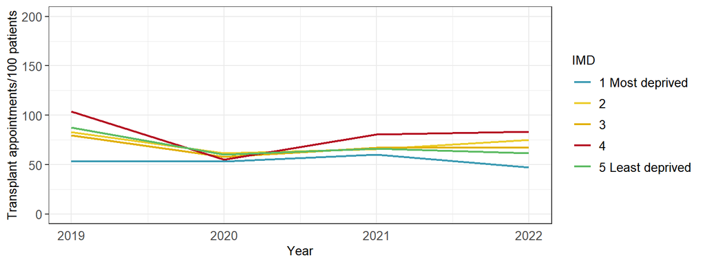

Transplant appointments by rural/urban

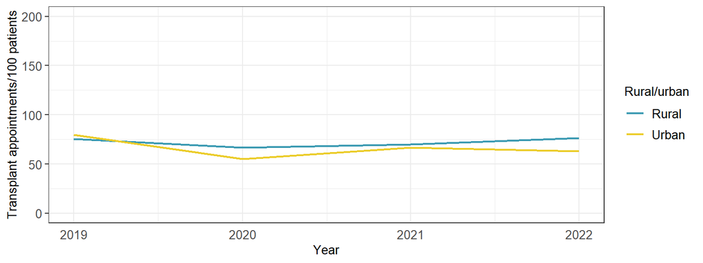

**GP interactions**

GP interactions (overall)

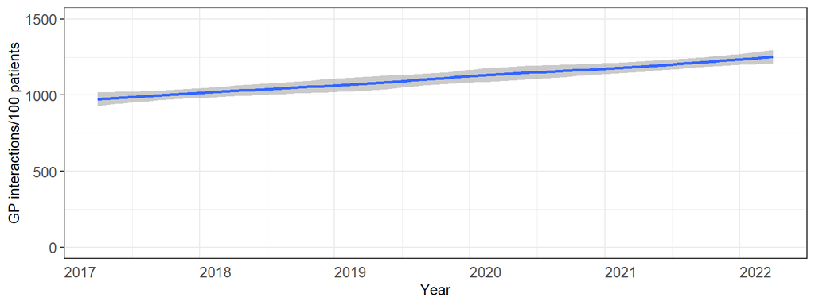

GP interactions by ethnicity

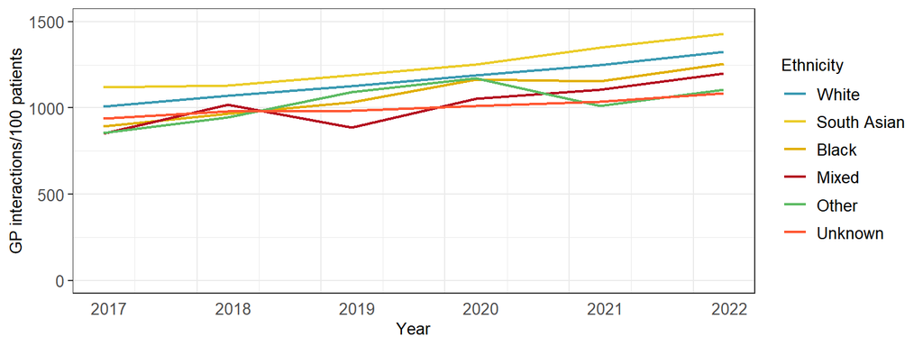

GP interactions by IMD

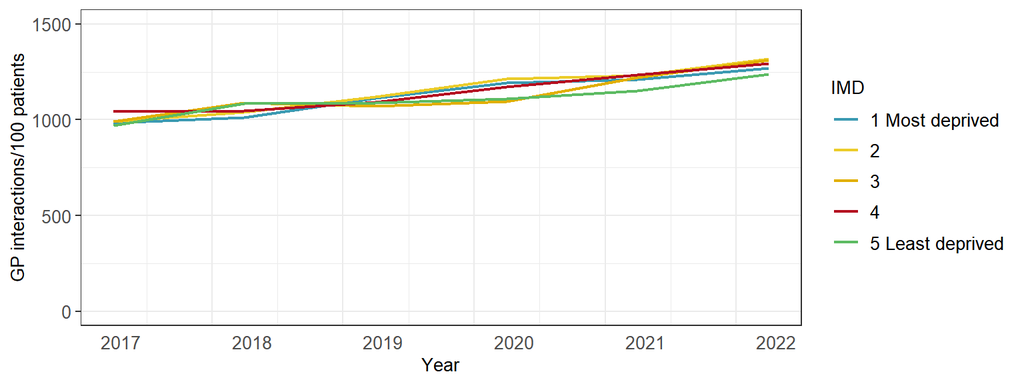

GP interactions by region

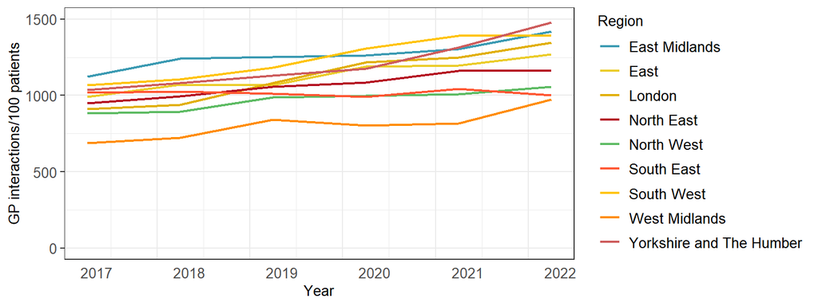

GP interactions by rural/urban

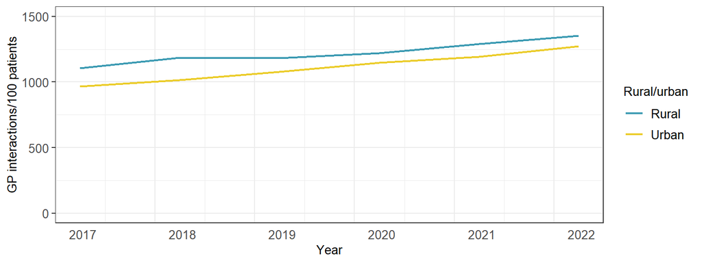

**AVF formations**

AVF formations (overall)

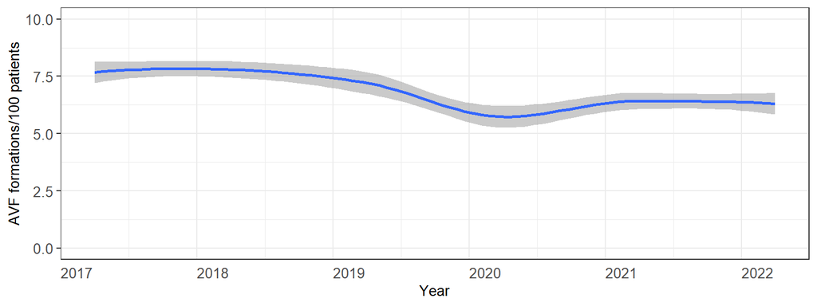

AVF formations by IMD

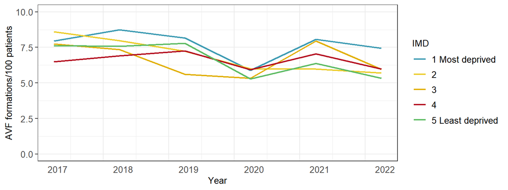

AVF formations by rural/urban

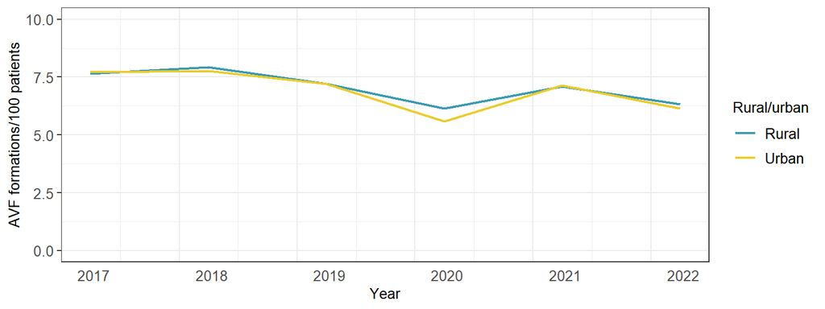

**PD insertions**

PD insertions (overall)

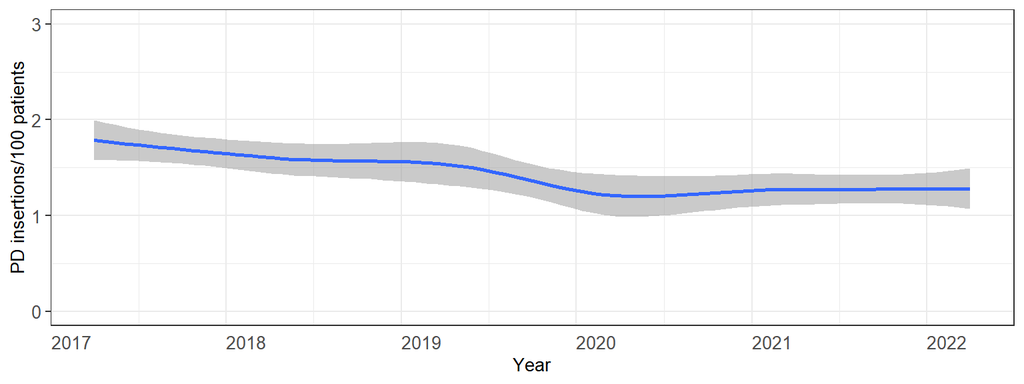

PD insertions by rural/urban

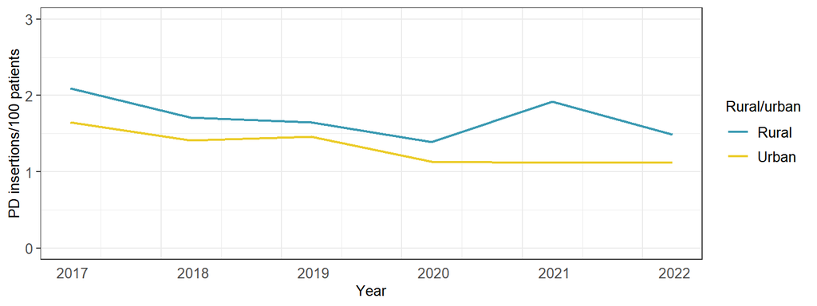